# WilloughbyHW9

Bryant Willoughby

2025-11-12

# Problem 1

Use the `prostate` data with `lpsa` as the response and the other variables as predictors. Implement the following variable selection methods to determine the “best” model

Data (Description): A study on 97 men with prostate cancer who were due to receive a radical prostatectomy.

```r
# help(prostate)
data(prostate)
attach(prostate)
head(prostate)
```

```
##       lcavol lweight age      lbph svi      lcp gleason pgg45     lpsa
## 1 -0.5798185  2.7695  50 -1.386294   0 -1.38629       6     0 -0.43078
## 2 -0.9942523  3.3196  58 -1.386294   0 -1.38629       6     0 -0.16252
## 3 -0.5108256  2.6912  74 -1.386294   0 -1.38629       7    20 -0.16252
## 4 -1.2039728  3.2828  58 -1.386294   0 -1.38629       6     0 -0.16252
## 5  0.7514161  3.4324  62 -1.386294   0 -1.38629       6     0  0.37156
## 6 -1.0498221  3.2288  50 -1.386294   0 -1.38629       6     0  0.76547
```

- Backward elimination

Best Model: `lpsa` ~ `lcavol` + `lweight` + `svi`

```r
g = lm(lpsa ~ ., data = prostate) #summary(g)
g = update(g, . ~ . - gleason); #summary(g)
g = update(g, . ~ . - lcp); #summary(g)
g = update(g, . ~ . - pgg45); #summary(g)
g = update(g, . ~ . - age); #summary(g)
g = update(g, . ~ . - lbph); summary(g)
```

```
##
## Call:
## lm(formula = lpsa ~ lcavol + lweight + svi, data = prostate)
##
## Residuals:
##      Min       1Q   Median       3Q      Max
## -1.72964 -0.45764  0.02812  0.46403  1.57013
##
## Coefficients:
##             Estimate Std. Error t value Pr(>|t|)
## (Intercept) -0.26809    0.54350  -0.493  0.62298
## lcavol       0.55164    0.07467   7.388  6.3e-11 ***
## lweight      0.50854    0.15017   3.386  0.00104 **
## svi          0.66616    0.20978   3.176  0.00203 **
## ---
## Signif. codes:  0 '***' 0.001 '**' 0.01 '*' 0.05 '.' 0.1 ' ' 1
##
## Residual standard error: 0.7168 on 93 degrees of freedom
## Multiple R-squared:  0.6264, Adjusted R-squared:  0.6144
## F-statistic: 51.99 on 3 and 93 DF,  p-value: < 2.2e-16
```

- AIC

Best model: `lpsa` ~ `lcavol` + `lweight` + `age` + `lbph` + `svi`

```r
g = lm(lpsa ~ ., data = prostate)
step(g)
```

```
## Start:  AIC=-58.32
## lpsa ~ lcavol + lweight + age + lbph + svi + lcp + gleason +
##     pgg45
##
##           Df Sum of Sq    RSS     AIC
## - gleason  1    0.0412 44.204 -60.231
## - pgg45    1    0.5258 44.689 -59.174
## - lcp      1    0.6740 44.837 -58.853
## <none>                 44.163 -58.322
## - age      1    1.5503 45.713 -56.975
## - lbph     1    1.6835 45.847 -56.693
## - lweight  1    3.5861 47.749 -52.749
## - svi      1    4.9355 49.099 -50.046
## - lcavol   1   22.3721 66.535 -20.567
##
## Step:  AIC=-60.23
## lpsa ~ lcavol + lweight + age + lbph + svi + lcp + pgg45
##
##           Df Sum of Sq    RSS     AIC
## - lcp      1    0.6623 44.867 -60.789
## <none>                 44.204 -60.231
## - pgg45    1    1.1920 45.396 -59.650
## - age      1    1.5166 45.721 -58.959
## - lbph     1    1.7053 45.910 -58.560
## - lweight  1    3.5462 47.750 -54.746
## - svi      1    4.8984 49.103 -52.037
## - lcavol   1   23.5039 67.708 -20.872
##
## Step:  AIC=-60.79
## lpsa ~ lcavol + lweight + age + lbph + svi + pgg45
##
##           Df Sum of Sq    RSS     AIC
## - pgg45    1    0.6590 45.526 -61.374
## <none>                 44.867 -60.789
## - age      1    1.2649 46.131 -60.092
## - lbph     1    1.6465 46.513 -59.293
## - lweight  1    3.5647 48.431 -55.373
## - svi      1    4.2503 49.117 -54.009
## - lcavol   1   25.4189 70.285 -19.248
##
## Step:  AIC=-61.37
## lpsa ~ lcavol + lweight + age + lbph + svi
##
##           Df Sum of Sq    RSS     AIC
## <none>                 45.526 -61.374
## - age      1    0.9592 46.485 -61.352
## - lbph     1    1.8568 47.382 -59.497
## - lweight  1    3.2251 48.751 -56.735
## - svi      1    5.9517 51.477 -51.456
## - lcavol   1   28.7665 74.292 -15.871
```

```
##
## Call:
## lm(formula = lpsa ~ lcavol + lweight + age + lbph + svi, data = prostate)
##
## Coefficients:
## (Intercept)       lcavol      lweight          age         lbph          svi
##     0.95100      0.56561      0.42369     -0.01489      0.11184      0.72095
```

- Adjusted $R^2$

Best model: `lpsa` ~ `lcavol` + `lweight` + `age` + `lbph` + `svi` + `lcp` + `pgg45`

```r
b = regsubsets(lpsa ~ ., data = prostate)
summary(b)
```

```
## Subset selection object
## Call: regsubsets.formula(lpsa ~ ., data = prostate)
## 8 Variables  (and intercept)
##         Forced in Forced out
## lcavol      FALSE      FALSE
## lweight     FALSE      FALSE
## age         FALSE      FALSE
## lbph        FALSE      FALSE
## svi         FALSE      FALSE
## lcp         FALSE      FALSE
## gleason     FALSE      FALSE
## pgg45       FALSE      FALSE
## 1 subsets of each size up to 8
## Selection Algorithm: exhaustive
##          lcavol lweight age lbph svi lcp gleason pgg45
## 1  ( 1 ) "*"    " "     " " " "  " " " " " "     " "
## 2  ( 1 ) "*"    "*"     " " " "  " " " " " "     " "
## 3  ( 1 ) "*"    "*"     " " " "  "*" " " " "     " "
## 4  ( 1 ) "*"    "*"     " " "*"  "*" " " " "     " "
## 5  ( 1 ) "*"    "*"     "*" "*"  "*" " " " "     " "
## 6  ( 1 ) "*"    "*"     "*" "*"  "*" " " " "     "*"
## 7  ( 1 ) "*"    "*"     "*" "*"  "*" "*" " "     "*"
## 8  ( 1 ) "*"    "*"     "*" "*"  "*" "*" "*"     "*"
```

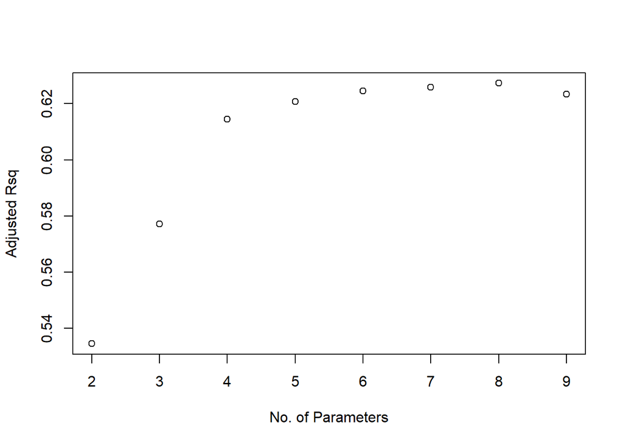

```r
# plot adj R^2 against p + 1
rs = summary(b)
plot(2:9, rs$adjr2, xlab = "No. of Parameters",
     ylab = "Adjusted Rsq")
```

```r
# select model with largest adjusted R^2
which.max(rs$adjr2)
```

```
## [1] 7
```

- Mallows Cp

Best model: `lpsa` ~ `lcavol` + `lweight` + `lbph` + `svi`

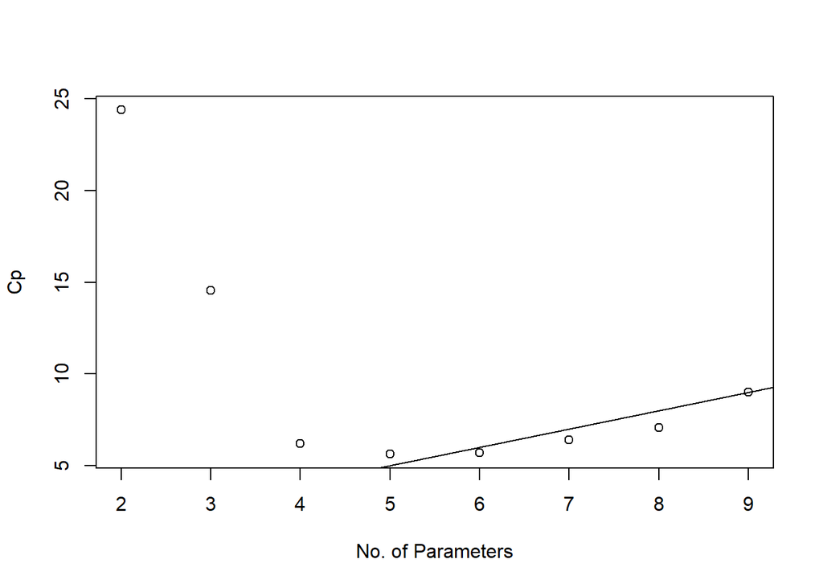

```r
plot(2:9, rs$cp, xlab = "No. of Parameters",
     ylab = "Cp")
abline(0, 1)
```

```r
which.min(rs$cp)
```

```
## [1] 4
```

# Problem 2

Using the `divusa` dataset with `divorce` as the response and the other variables as predictors, repeat the work of the first question.

Data (Description): Divorce rates in the USA from 1920-1996.

```r
# help(divusa)
data(divusa)
attach(divusa)
head(divusa)
```

```
##   year divorce unemployed femlab marriage birth military
## 1 1920     8.0        5.2  22.70     92.0 117.9   3.2247
## 2 1921     7.2       11.7  22.79     83.0 119.8   3.5614
## 3 1922     6.6        6.7  22.88     79.7 111.2   2.4553
## 4 1923     7.1        2.4  22.97     85.2 110.5   2.2065
## 5 1924     7.2        5.0  23.06     80.3 110.9   2.2889
## 6 1925     7.2        3.2  23.15     79.2 106.6   2.1735
```

- Backward elimination

Best model: divorce ~ year + femlab + marriage + birth + military

```r
g = lm(divorce ~ ., data = divusa); #summary(g)
g = update(g, . ~ . - unemployed); summary(g)
```

```
##
## Call:
## lm(formula = divorce ~ year + femlab + marriage + birth + military,
##     data = divusa)
##
## Residuals:
##     Min      1Q  Median      3Q     Max
## -2.7586 -1.0494 -0.0424  0.7201  3.3075
##
## Coefficients:
##              Estimate Std. Error t value Pr(>|t|)
## (Intercept) 405.61670   95.13189   4.264 6.09e-05 ***
## year         -0.21790    0.05078  -4.291 5.52e-05 ***
## femlab        0.85480    0.10276   8.318 4.29e-12 ***
## marriage      0.15934    0.02140   7.447 1.76e-10 ***
## birth        -0.11012    0.01266  -8.700 8.43e-13 ***
## military     -0.04120    0.01360  -3.030  0.00341 **
## ---
## Signif. codes:  0 '***' 0.001 '**' 0.01 '*' 0.05 '.' 0.1 ' ' 1
##
## Residual standard error: 1.511 on 71 degrees of freedom
## Multiple R-squared:  0.9336, Adjusted R-squared:  0.929
## F-statistic: 199.7 on 5 and 71 DF,  p-value: < 2.2e-16
```

- AIC

Best model: divorce ~ year + femlab + marriage + birth + military

```r
g = lm(divorce ~ ., data = divusa)
step(g)
```

```
## Start:  AIC=70.41
## divorce ~ year + unemployed + femlab + marriage + birth + military
##
##              Df Sum of Sq    RSS     AIC
## - unemployed  1     1.925 162.12  69.330
## <none>                    160.20  70.410
## - military    1    22.231 182.43  78.417
## - year        1    33.199 193.40  82.912
## - marriage    1    90.468 250.66 102.884
## - femlab      1   113.214 273.41 109.572
## - birth       1   144.897 305.10 118.015
##
## Step:  AIC=69.33
## divorce ~ year + femlab + marriage + birth + military
##
##            Df Sum of Sq    RSS     AIC
## <none>                  162.12  69.330
## - military  1    20.957 183.08  76.691
## - year      1    42.054 204.18  85.089
## - marriage  1   126.643 288.77 111.779
## - femlab    1   158.003 320.13 119.718
## - birth     1   172.826 334.95 123.203
```

```
##
## Call:
## lm(formula = divorce ~ year + femlab + marriage + birth + military,
##     data = divusa)
##
## Coefficients:
## (Intercept)         year       femlab     marriage        birth     military
##    405.6167      -0.2179       0.8548       0.1593      -0.1101      -0.0412
```

- Adjusted $R^2$

Best model: divorce ~ year + femlab + marriage + birth + military

```r
b = regsubsets(divorce ~ ., data = divusa)
summary(b)
```

```
## Subset selection object
## Call: regsubsets.formula(divorce ~ ., data = divusa)
## 6 Variables  (and intercept)
##            Forced in Forced out
## year           FALSE      FALSE
## unemployed     FALSE      FALSE
## femlab         FALSE      FALSE
## marriage       FALSE      FALSE
## birth          FALSE      FALSE
## military       FALSE      FALSE
## 1 subsets of each size up to 6
## Selection Algorithm: exhaustive
##          year unemployed femlab marriage birth military
## 1  ( 1 ) " "  " "        "*"    " "      " "   " "
## 2  ( 1 ) " "  " "        "*"    " "      "*"   " "
## 3  ( 1 ) " "  " "        "*"    "*"      "*"   " "
## 4  ( 1 ) "*"  " "        "*"    "*"      "*"   " "
## 5  ( 1 ) "*"  " "        "*"    "*"      "*"   "*"
## 6  ( 1 ) "*"  "*"        "*"    "*"      "*"   "*"
```

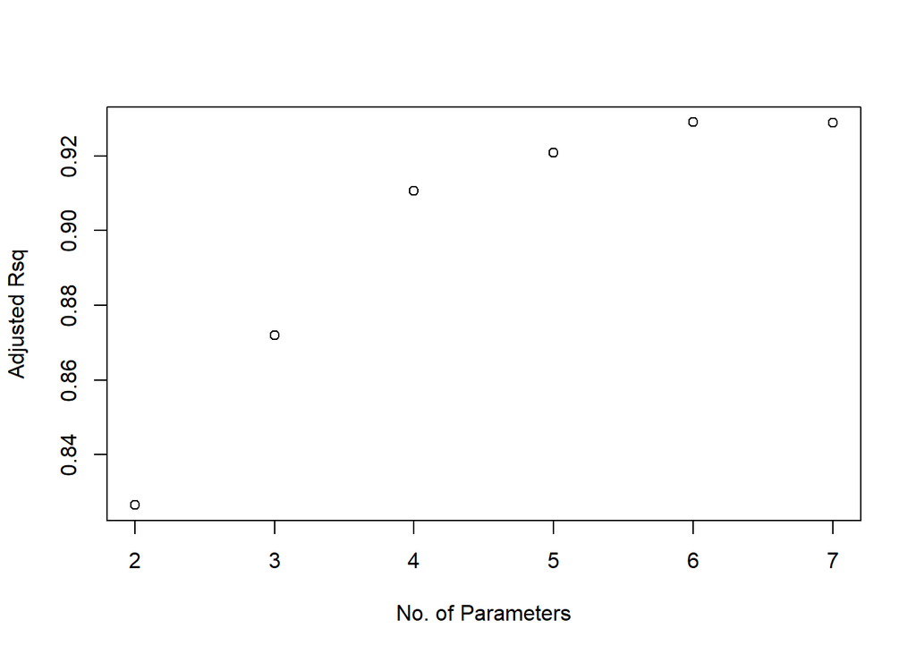

```r
# plot adj R^2 against p + 1
rs = summary(b)
plot(2:7, rs$adjr2, xlab = "No. of Parameters",
     ylab = "Adjusted Rsq")
```

```r
# select model with largest adjusted R^2
which.max(rs$adjr2)
```

```
## [1] 5
```

- Mallows Cp

Best model: divorce ~ year + femlab + marriage + birth + military

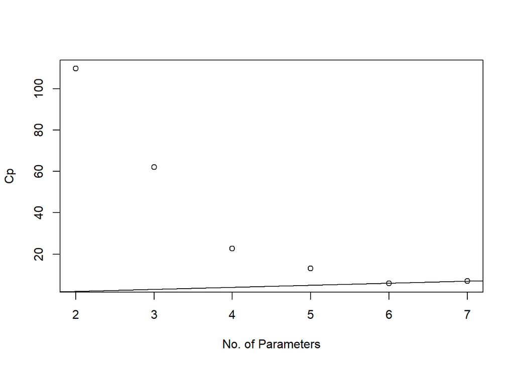

```r
plot(2:7, rs$cp, xlab = "No. of Parameters",
     ylab = "Cp")
abline(0, 1)
```

```r
which.min(rs$cp)
```

```
## [1] 5
```